# Heart Disease

**Fasting BS**

```r
table(heartanalysis$FastingBS)
```

```
##
##   0   1
## 704 214
```

```r
prop.table(table(heartanalysis$FastingBS))
```

```
##
##         0         1
## 0.7668845 0.2331155
```

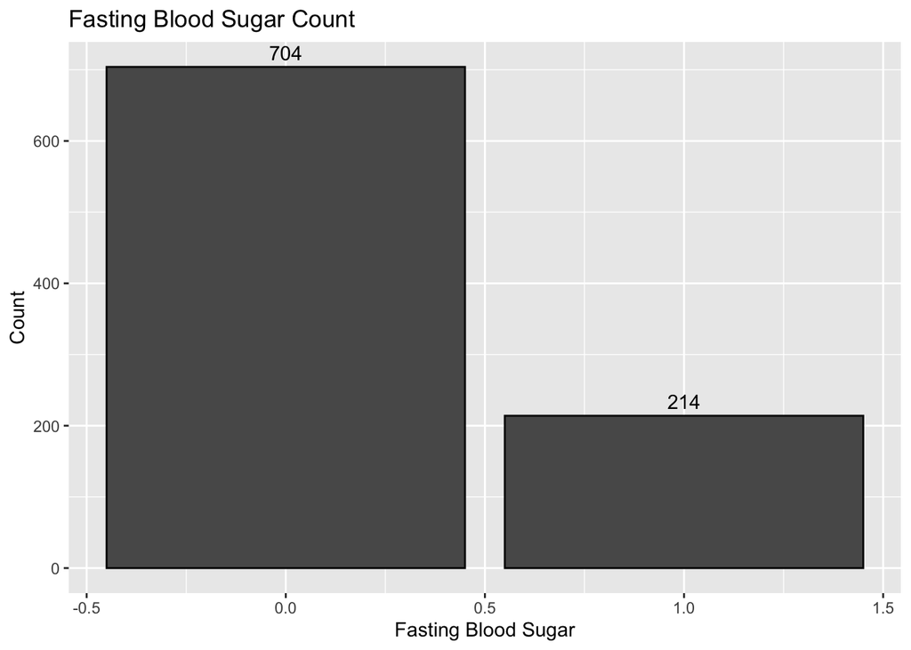

```r
ggplot(data = heartanalysis, aes(x = FastingBS, fill = FastingBS)) +
  geom_bar(stat = "count", color = "black") +
  geom_text(stat = "count", aes(label = stat(count)), vjust = -0.5) +
  labs(x = "Fasting Blood Sugar", y = "Count", title = "Fasting Blood Sugar Count") +
  guides(fill = FALSE)
```

- 214 patients registered fasting blood sugar levels that were greater than 120 mg/dl while 704 patients had less than 120 mg/dl.

**RestingECG**

```r
table(heartanalysis$RestingECG)
```

```
##
##    LVH Normal     ST
##    188    552    178
```

```r
prop.table(table(heartanalysis$RestingECG))
```

```
##
##       LVH    Normal        ST
## 0.2047930 0.6013072 0.1938998
```

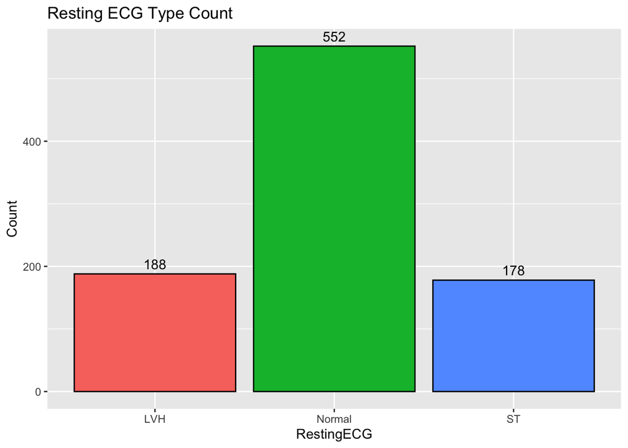

```r
ggplot(data = heartanalysis, aes(x = RestingECG, fill = RestingECG)) +
  geom_bar(stat = "count", color = "black") +
  geom_text(stat = "count", aes(label = stat(count)), vjust = -0.5) +
  labs(x = "RestingECG", y = "Count", title = "Resting ECG Type Count") +
  guides(fill = FALSE)
```

- 188 patients showed probable or definite left ventricular hypertrophy by Estes’ criteria(LVH).
- 552 patients had normal resting electrocardiogram(RestingECG) results.
- 178 patients had ST-T wave abnormality.

**MaxHR**

```r
table(heartanalysis$MaxHR)
```

```
##
##  60  63  67  69  70  71  72  73  77  78  80  82  83  84  86  87  88  90  91  92
##   1   1   1   1   1   1   2   1   1   1   2   3   1   3   4   1   2   3   1   6
##  93  94  95  96  97  98  99 100 102 103 104 105 106 107 108 109 110 111 112 113
##   2   4   2   7   3   9   7  14   4   4   2  11   5   1   8   5  23   5  13   5
## 114 115 116 117 118 119 120 121 122 123 124 125 126 127 128 129 130 131 132 133
##   6  16   9   6  12   5  36   5  20   7   9  21  12   8  14   4  33   7  11   5
## 134 135 136 137 138 139 140 141 142 143 144 145 146 147 148 149 150 151 152 153
##   6  15   6   7  14   6  41   6  14  10  13  14   6   5  11   6  43   5  11   5
## 154 155 156 157 158 159 160 161 162 163 164 165 166 167 168 169 170 171 172 173
##  12  14  10   7   8   5  25   7  13  10   4  11   5   2   8   6  20   4  10   7
## 174 175 176 177 178 179 180 181 182 184 185 186 187 188 190 192 194 195 202
##   7  10   2   1   6   6  10   2   6   4   4   2   1   2   2   1   1   1   1
```

```r
prop.table(table(heartanalysis$MaxHR))
```

```
##
##          60          63          67          69          70          71
## 0.001089325 0.001089325 0.001089325 0.001089325 0.001089325 0.001089325
##          72          73          77          78          80          82
## 0.002178649 0.001089325 0.001089325 0.001089325 0.002178649 0.003267974
##          83          84          86          87          88          90
## 0.001089325 0.003267974 0.004357298 0.001089325 0.002178649 0.003267974
##          91          92          93          94          95          96
## 0.001089325 0.006535948 0.002178649 0.004357298 0.002178649 0.007625272
##          97          98          99         100         102         103
## 0.003267974 0.009803922 0.007625272 0.015250545 0.004357298 0.004357298
##         104         105         106         107         108         109
## 0.002178649 0.011982571 0.005446623 0.001089325 0.008714597 0.005446623
##         110         111         112         113         114         115
## 0.025054466 0.005446623 0.014161220 0.005446623 0.006535948 0.017429194
##         116         117         118         119         120         121
## 0.009803922 0.006535948 0.013071895 0.005446623 0.039215686 0.005446623
##         122         123         124         125         126         127
## 0.021786492 0.007625272 0.009803922 0.022875817 0.013071895 0.008714597
##         128         129         130         131         132         133
## 0.015250545 0.004357298 0.035947712 0.007625272 0.011982571 0.005446623
##         134         135         136         137         138         139
## 0.006535948 0.016339869 0.006535948 0.007625272 0.015250545 0.006535948
##         140         141         142         143         144         145
## 0.044662309 0.006535948 0.015250545 0.010893246 0.014161220 0.015250545
##         146         147         148         149         150         151
## 0.006535948 0.005446623 0.011982571 0.006535948 0.046840959 0.005446623
##         152         153         154         155         156         157
## 0.011982571 0.005446623 0.013071895 0.015250545 0.010893246 0.007625272
##         158         159         160         161         162         163
## 0.008714597 0.005446623 0.027233115 0.007625272 0.014161220 0.010893246
##         164         165         166         167         168         169
## 0.004357298 0.011982571 0.005446623 0.002178649 0.008714597 0.006535948
##         170         171         172         173         174         175
## 0.021786492 0.004357298 0.010893246 0.007625272 0.007625272 0.010893246
##         176         177         178         179         180         181
## 0.002178649 0.001089325 0.006535948 0.006535948 0.010893246 0.002178649
##         182         184         185         186         187         188
## 0.006535948 0.004357298 0.004357298 0.002178649 0.001089325 0.002178649
##         190         192         194         195         202
## 0.002178649 0.001089325 0.001089325 0.001089325 0.001089325
```

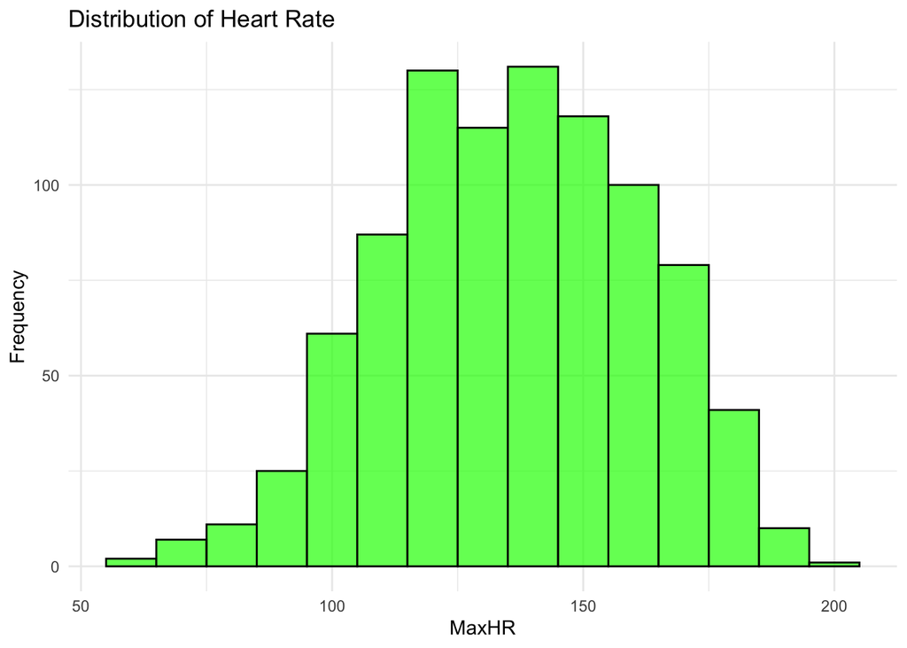

```r
ggplot(data=heartanalysis, aes(x = MaxHR)) +
  geom_histogram(binwidth = 10, fill = "green", color = "black", alpha = 0.7) +
  labs(title = "Distribution of Heart Rate", x = "MaxHR", y = "Frequency") +
  theme_minimal()
```

- Majority of the patients had a maximum heart rate between 100 and 170.

**Exercise Angina**

```r
table(heartanalysis$ExerciseAngina)
```

```
##
##   N   Y
## 547 371
```

```r
prop.table(table(heartanalysis$ExerciseAngina))
```

```
##
##         N         Y
## 0.5958606 0.4041394
```

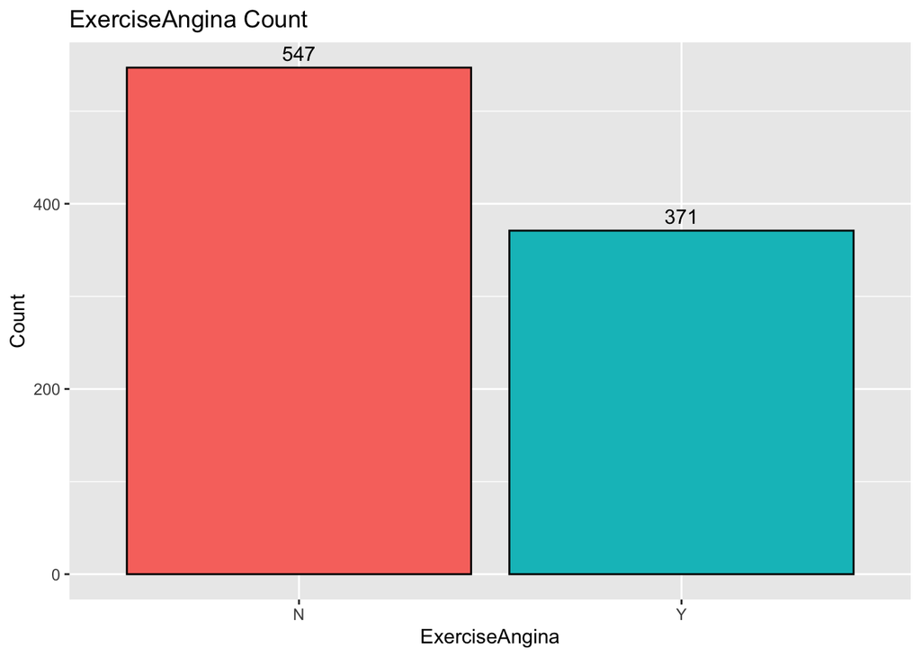

```r
ggplot(data = heartanalysis, aes(x = ExerciseAngina, fill = ExerciseAngina)) +
  geom_bar(stat = "count", color = "black") +
  geom_text(stat = "count", aes(label = stat(count)), vjust = -0.5) +
  labs(x = "ExerciseAngina", y = "Count", title = "ExerciseAngina Count") +
  guides(fill = FALSE)
```

- Majority of the patients (547) didn’t have exercised-induced angina.

**Old Peak**

```r
table(heartanalysis$Oldpeak)
```

```
##
## -2.6   -2 -1.5 -1.1   -1 -0.9 -0.8 -0.7 -0.5 -0.1    0  0.1  0.2  0.3  0.4  0.5
##    1    1    1    1    2    1    1    1    2    2  368   14   22   11   11   19
##  0.6  0.7  0.8  0.9    1  1.1  1.2  1.3  1.4  1.5  1.6  1.7  1.8  1.9    2  2.1
##   14    7   16    4   86    7   26    7   18   53   16    6   17    7   76    2
##  2.2  2.3  2.4  2.5  2.6  2.8  2.9    3  3.1  3.2  3.4  3.5  3.6  3.7  3.8    4
##    5    2    4   16    7    7    1   28    1    2    3    2    4    1    1    8
##  4.2  4.4    5  5.6  6.2
##    2    1    1    1    1
```

```r
prop.table(table(heartanalysis$Oldpeak))
```

```
##
##        -2.6          -2        -1.5        -1.1          -1        -0.9
## 0.001089325 0.001089325 0.001089325 0.001089325 0.002178649 0.001089325
##        -0.8        -0.7        -0.5        -0.1           0         0.1
## 0.001089325 0.001089325 0.002178649 0.002178649 0.400871460 0.015250545
##         0.2         0.3         0.4         0.5         0.6         0.7
## 0.023965142 0.011982571 0.011982571 0.020697168 0.015250545 0.007625272
##         0.8         0.9           1         1.1         1.2         1.3
## 0.017429194 0.004357298 0.093681917 0.007625272 0.028322440 0.007625272
##         1.4         1.5         1.6         1.7         1.8         1.9
## 0.019607843 0.057734205 0.017429194 0.006535948 0.018518519 0.007625272
##           2         2.1         2.2         2.3         2.4         2.5
## 0.082788671 0.002178649 0.005446623 0.002178649 0.004357298 0.017429194
##         2.6         2.8         2.9           3         3.1         3.2
## 0.007625272 0.007625272 0.001089325 0.030501089 0.001089325 0.002178649
##         3.4         3.5         3.6         3.7         3.8           4
## 0.003267974 0.002178649 0.004357298 0.001089325 0.001089325 0.008714597
##         4.2         4.4           5         5.6         6.2
## 0.002178649 0.001089325 0.001089325 0.001089325 0.001089325
```

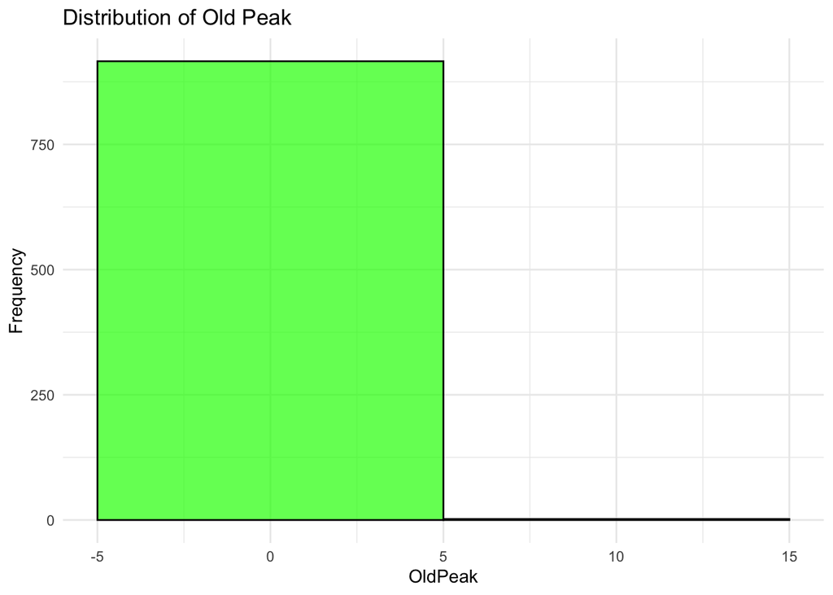

```r
ggplot(data=heartanalysis, aes(x = Oldpeak)) +
  geom_histogram(binwidth = 10, fill = "green", color = "black", alpha = 0.7) +
  labs(title = "Distribution of Old Peak", x = "OldPeak", y = "Frequency") +
  theme_minimal()
```

**ST_Slope**

```r
table(heartanalysis$ST_Slope)
```

```
##
## Down Flat   Up
##   63  460  395
```

```r
prop.table(table(heartanalysis$ST_Slope))
```

```
##
##       Down       Flat         Up
## 0.06862745 0.50108932 0.43028322
```

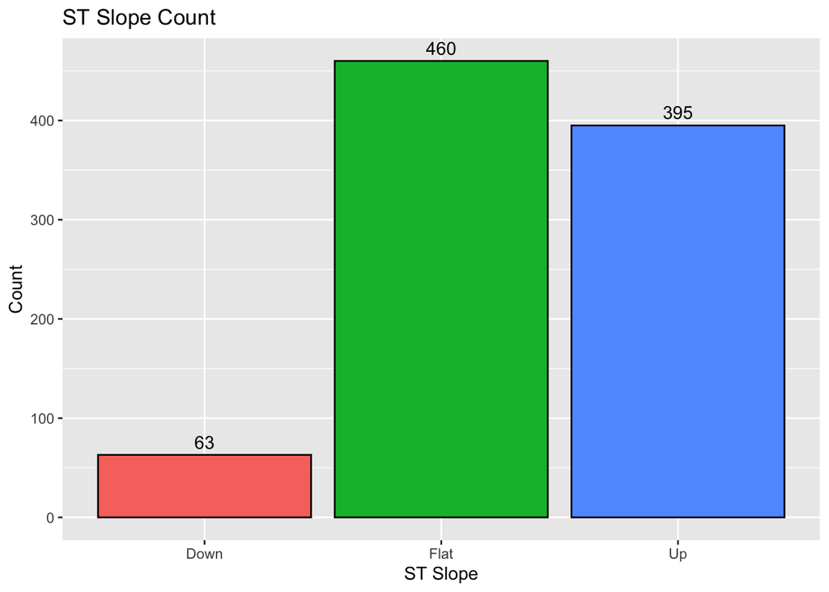

```r
ggplot(data = heartanalysis, aes(x = ST_Slope, fill = ST_Slope)) +
  geom_bar(stat = "count", color = "black") +
  geom_text(stat = "count", aes(label = stat(count)), vjust = -0.5) +
  labs(x = "ST Slope", y = "Count", title = "ST Slope Count") +
  guides(fill = FALSE)
```

- There were 63 patients with downsloping peak exercise ST segment.
- There were 460 patients with flat peak exercise ST segment.
- There were 395 patients with upsloping peak exercise ST segment.